# R Notebook

# Load libraries

```r
library(psych)
library(mediation)
library(ppcor)
library(tidyverse)
```

# Read in data

```r
med <- read_csv("mediate2.csv")
```

# Class Demo

## Baron & Kenny Plausibility: Examine Correlations between variables

## Analysis 1: Test the hypothesis that X4 mediates the relationship between X1 and Y1

```r
analysis2 <- select(med, X3, X4, Y1)
cor(analysis2)
```

[output not shown]

r xy = 0.3465 (c path) r xm = 0.043 (a path) r my = 0.4105 (b path)

We do not have justification to test this mdiation hypothesis because the a path has a negligible effect.

## Analysis 2: Test the hypothesis that X4 mediates the relationship between X3 and Y1

r xy = 0.5053 r xm = 0.3425 r my = 0.4105

We do have justifaction to test this mediation hypothesis because all paths have a moderate effect

```r
spcor.test(x = med$X3, y = med$Y1, z = med$X4)
```

| estimate | p.value | statistic | n | gp | Method |
| --- | --- | --- | --- | --- | --- |
| 0.3999824 | 2.030191e-24 | 10.66313 | 600 | 1 | pearson |

r y(x.m) = 0.3999. This is 0.11 smaller than r xy (0.5053), indicating that partial mediation is plausible. In other words, there is a portion of the relation betweeen x and y that involves m.

### Regression method

```r
m1 <- lm(Y1 ~ X3      , data = med)
m2 <- lm(Y1 ~ X3 + X4 , data = med)

anova(m1,m2)
```

```
Analysis of Variance Table

Model 1: Y1 ~ X3
Model 2: Y1 ~ X3 + X4
  Res.Df    RSS Df Sum of Sq      F    Pr(>F)
1    598 373.91
2    597 341.85  1    32.062 55.993 2.617e-13 ***
---
Signif. codes:  0 ‘***’ 0.001 ‘**’ 0.01 ‘*’ 0.05 ‘.’ 0.1 ‘ ’ 1
```

### mediate in psych

```r
fitmed <- psych::mediate(Y1 ~ X3 + (X4), data = med)
summary(fitmed)
```

[output not shown]

### Mediate in mediation package

```r
fitM <- lm(X4 ~ X3, data = med)
fitY <- lm(Y1 ~ X3 + X4, data = med)


fitmed <- mediation::mediate(fitM, fitY, treat = "X3", mediator = "X4")
summary(fitmed)
```

```
Causal Mediation Analysis

Quasi-Bayesian Confidence Intervals

               Estimate 95% CI Lower 95% CI Upper p-value
ACME             0.0534       0.0356         0.07  <2e-16 ***
ADE              0.2405       0.1984         0.28  <2e-16 ***
Total Effect     0.2939       0.2533         0.33  <2e-16 ***
Prop. Mediated   0.1807       0.1234         0.25  <2e-16 ***
---
Signif. codes:  0 ‘***’ 0.001 ‘**’ 0.01 ‘*’ 0.05 ‘.’ 0.1 ‘ ’ 1

Sample Size Used: 600


Simulations: 1000
```

```r
cor(med)
```

```
           X1          X2         X3         X4         X5         Y1
X1 1.00000000  0.03946291 0.03657073 0.04344269  0.1020180  0.3465506
X2 0.03946291  1.00000000 0.08889150 0.06447405 -0.1310097 -0.3227619
X3 0.03657073  0.08889150 1.00000000 0.34246913  0.7331822  0.5053060
X4 0.04344269  0.06447405 0.34246913 1.00000000  0.4068431  0.4104644
X5 0.10201803 -0.13100973 0.73318217 0.40684310  1.0000000  0.6405100
Y1 0.34655064 -0.32276194 0.50530603 0.41046440  0.6405100  1.0000000
```

## Analysis 3: Test the hypothesis that X4 mediates the relationship between X5 and Y1

r xy = 0.6405 r xm = 0.4068 r my = 0.4105

We do have justifaction to test this mediation hypothesis because all paths have a moderate effect

```r
spcor.test(x = med$X5, y = med$Y1, z = med$X4)
```

| estimate | p.value | statistic | n | gp | Method |
| --- | --- | --- | --- | --- | --- |
| 0.5192757 | 1.150621e-42 | 14.84632 | 600 | 1 | pearson |

r y(x.m) = 0.5192. This is 0.12 smaller than r xy (0.6405), indicating that partial mediation is plausible. In other words, there is a portion of the relation betweeen x and y that involves m.

### Regression method

```r
m1 <- lm(Y1 ~ X5      , data = med)
m2 <- lm(Y1 ~ X5 + X4 , data = med)

anova(m1,m2)
```

```
Analysis of Variance Table

Model 1: Y1 ~ X5
Model 2: Y1 ~ X5 + X4
  Res.Df    RSS Df Sum of Sq      F    Pr(>F)
1    598 296.12
2    597 282.61  1    13.517 28.553 1.299e-07 ***
---
Signif. codes:  0 ‘***’ 0.001 ‘**’ 0.01 ‘*’ 0.05 ‘.’ 0.1 ‘ ’ 1
```

### mediate in psych

```r
fitmed <- psych::mediate(Y1 ~ X5 + (X4), data = med)
summary(fitmed)
```

[output not shown]

### Mediate in mediation package

```r
fitM <- lm(X4 ~ X5, data = med)
fitY <- lm(Y1 ~ X5 + X4, data = med)


fitmed <- mediation::mediate(fitM, fitY, treat = "X5", mediator = "X4")
summary(fitmed)
```

```
Causal Mediation Analysis

Quasi-Bayesian Confidence Intervals

               Estimate 95% CI Lower 95% CI Upper p-value
ACME            0.00548      0.00337         0.01  <2e-16 ***
ADE             0.04279      0.03790         0.05  <2e-16 ***
Total Effect    0.04827      0.04368         0.05  <2e-16 ***
Prop. Mediated  0.11242      0.06993         0.16  <2e-16 ***
---
Signif. codes:  0 ‘***’ 0.001 ‘**’ 0.01 ‘*’ 0.05 ‘.’ 0.1 ‘ ’ 1

Sample Size Used: 600


Simulations: 1000
```

# Class Activity

## Read data

```r
slp <- read_csv("slpdata.csv")
```

```r
slp <- dplyr::select(slp, sleep, hygiene, lifesat)
```

## Baron & Kenny Plausibility: Examine Correlations between variables

```r
cor(slp)
```

```
            sleep   hygiene  lifesat
sleep   1.0000000 0.7331822 0.640510
hygiene 0.7331822 1.0000000 0.505306
lifesat 0.6405100 0.5053060 1.000000
```

## Analysis 1: Test the hypothesis that sleep efficiency mediates the relationship between sleep hygiene and life satisfaction.

r xy = 0.5053 r xm = 0.7332 r my = 0.6405

We do have justifaction to test this mediation hypothesis because all paths have a moderate to large effect

```r
spcor.test(x = slp$hygiene, y = slp$lifesat, z = slp$sleep)
```

| estimate | p.value | statistic | n | gp | Method |
| --- | --- | --- | --- | --- | --- |
| 0.0464816 | 0.2560191 | 1.136941 | 600 | 1 | pearson |

### mediate in psych

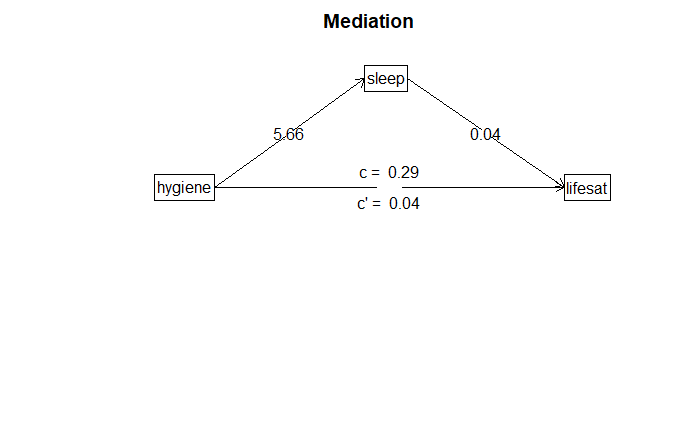

```r
fitmed <- psych::mediate(lifesat ~ hygiene + (sleep), data = slp)
```

```r
summary(fitmed)
```

```
Call: psych::mediate(y = lifesat ~ hygiene + (sleep), data = slp)

Direct effect estimates (traditional regression)    (c')
```

|  | lifesat | se | t | df | Prob |
| --- | --- | --- | --- | --- | --- |
| Intercept | 0.75 | 0.17 | 4.54 | 597 | 6.79e-06 |
| hygiene | 0.04 | 0.03 | 1.67 | 597 | 9.47e-02 |
| sleep | 0.04 | 0.00 | 12.66 | 597 | 1.01e-32 |

```
R = 0.64 R2 = 0.41   F = 210.03 on 2 and 597 DF   p-value:  8.64e-70

 Total effect estimates (c)
```

|  | lifesat | se | t | df | Prob |
| --- | --- | --- | --- | --- | --- |
| Intercept | 2.29 | 0.13 | 18.03 | 598 | 2.20e-58 |
| hygiene | 0.29 | 0.02 | 14.32 | 598 | 3.34e-40 |

```
 'a'  effect estimates
```

|  | sleep | se | t | df | Prob |
| --- | --- | --- | --- | --- | --- |
| Intercept | 34.98 | 1.33 | 26.31 | 598 | 5.99e-102 |
| hygiene | 5.66 | 0.21 | 26.37 | 598 | 3.16e-102 |

```
 'b'  effect estimates
```

|  | lifesat | se | t | df | Prob |
| --- | --- | --- | --- | --- | --- |
| sleep | 0.04 | 0 | 12.67 | 598 | 8.96e-33 |

```
 'ab'  effect estimates (through mediators)
```

|  | lifesat | boot | sd | lower | upper |
| --- | --- | --- | --- | --- | --- |
| hygiene | 0.25 | 0.25 | 0.02 | 0.21 | 0.29 |

### Mediate in mediation package

```r
fitM <- lm(sleep   ~ hygiene        , data = slp)
fitY <- lm(lifesat ~ hygiene + sleep, data = slp)


fitmed <- mediation::mediate(fitM, fitY, treat = "hygiene", mediator = "sleep")
summary(fitmed)
```

```
Causal Mediation Analysis

Quasi-Bayesian Confidence Intervals

               Estimate 95% CI Lower 95% CI Upper p-value
ACME            0.24840      0.20424         0.29  <2e-16 ***
ADE             0.04639     -0.00628         0.10   0.082 .
Total Effect    0.29479      0.25382         0.34  <2e-16 ***
Prop. Mediated  0.84345      0.67579         1.02  <2e-16 ***
---
Signif. codes:  0 ‘***’ 0.001 ‘**’ 0.01 ‘*’ 0.05 ‘.’ 0.1 ‘ ’ 1

Sample Size Used: 600


Simulations: 1000
```

## Analysis 2: Test the hypothesis that sleep efficiency mediates the relationship between anxiety and life satisfaction.

### Baron & Kenny Plausibility: Examine Correlations between variables

```r
cor(slp)
```

```
            sleep   hygiene  lifesat
sleep   1.0000000 0.7331822 0.640510
hygiene 0.7331822 1.0000000 0.505306
lifesat 0.6405100 0.5053060 1.000000
```

We do NOT have justifaction to test this mediation hypothesis because path a has a negligible correlation effect size (-.1310)

```r
#spcor.test(x = slp$anxiety, y = slp$lifesat, z = slp$sleep)
```